# SVM challenge

Transform this regression problem into a binary classifier and clean up the feature set. You can choose whether or not to include nutritional information, but try to cut your feature set down to the 30 most valuable features.

Good luck!

When you've finished that, also take a moment to think about bias. Is there anything in this dataset that makes you think it could be biased, perhaps extremely so?

There is. Several things in fact, but most glaringly is that we don't actually have a random sample. It could be, and probably is, that the people more likely to choose some kinds of recipes are more likely to give high reviews.

After all, people who eat chocolate might just be happier people.

```python
import numpy as np
import pandas as pd
import scipy
import matplotlib.pyplot as plt
import seaborn as sns
%matplotlib inline

sns.set_style('darkgrid')
```

```python
recipes = pd.read_csv('https://tf-assets-prod.s3.amazonaws.com/tf-curric/data-science/epi_r.csv')
recipes.head()
```

|  | title | rating | calories | protein | fat | sodium | #cakeweek | #wasteless | 22-minute meals | 3-ingredient recipes | ... | yellow squash | yogurt | yonkers | yuca | zucchini | cookbooks | leftovers | snack | snack week | turkey |
| --- | --- | --- | --- | --- | --- | --- | --- | --- | --- | --- | --- | --- | --- | --- | --- | --- | --- | --- | --- | --- | --- |
| 0 | Lentil, Apple, and Turkey Wrap | 2.500 | 426.0 | 30.0 | 7.0 | 559.0 | 0.0 | 0.0 | 0.0 | 0.0 | ... | 0.0 | 0.0 | 0.0 | 0.0 | 0.0 | 0.0 | 0.0 | 0.0 | 0.0 | 1.0 |
| 1 | Boudin Blanc Terrine with Red Onion Confit | 4.375 | 403.0 | 18.0 | 23.0 | 1439.0 | 0.0 | 0.0 | 0.0 | 0.0 | ... | 0.0 | 0.0 | 0.0 | 0.0 | 0.0 | 0.0 | 0.0 | 0.0 | 0.0 | 0.0 |
| 2 | Potato and Fennel Soup Hodge | 3.750 | 165.0 | 6.0 | 7.0 | 165.0 | 0.0 | 0.0 | 0.0 | 0.0 | ... | 0.0 | 0.0 | 0.0 | 0.0 | 0.0 | 0.0 | 0.0 | 0.0 | 0.0 | 0.0 |
| 3 | Mahi-Mahi in Tomato Olive Sauce | 5.000 | NaN | NaN | NaN | NaN | 0.0 | 0.0 | 0.0 | 0.0 | ... | 0.0 | 0.0 | 0.0 | 0.0 | 0.0 | 0.0 | 0.0 | 0.0 | 0.0 | 0.0 |
| 4 | Spinach Noodle Casserole | 3.125 | 547.0 | 20.0 | 32.0 | 452.0 | 0.0 | 0.0 | 0.0 | 0.0 | ... | 0.0 | 0.0 | 0.0 | 0.0 | 0.0 | 0.0 | 0.0 | 0.0 | 0.0 | 0.0 |

5 rows × 680 columns

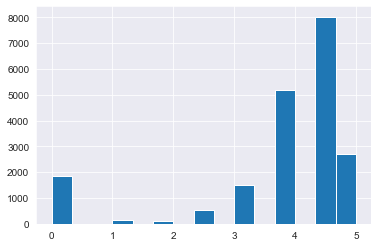

```python
recipes.rating.hist(bins=15)
```

```python
recipes.rating.describe()
```

```
count    20052.000000
mean         3.714467
std          1.340829
min          0.000000
25%          3.750000
50%          4.375000
75%          4.375000
max          5.000000
Name: rating, dtype: float64
```

```python
recipes.rating.unique()
```

```
array([2.5  , 4.375, 3.75 , 5.   , 3.125, 1.875, 0.   , 1.25 ])
```

```python
recipes['rating bin']= pd.cut(recipes.rating, bins=[0.0, 3.5, 5.0], labels=['Average', 'Great'], include_lowest=True)
```

```python
recipes.info()
```

```
<class 'pandas.core.frame.DataFrame'>
RangeIndex: 20052 entries, 0 to 20051
Columns: 681 entries, title to rating bin
dtypes: category(1), float64(679), object(1)
memory usage: 104.0+ MB
```

```python
# Count nulls
null_pct = recipes.isnull().sum()/recipes.isnull().count()
print('Percentage Missing:\n',null_pct[null_pct>0]*100)
```

```
Percentage Missing:
 calories    20.531618
protein     20.756034
fat         20.860762
sodium      20.541592
dtype: float64
```

```python
#Create dummies for target
target_dummy= pd.get_dummies(recipes['rating bin'], drop_first=True)
```

```python
recipes= pd.concat([recipes, target_dummy], axis=1)
```

```python
recipes.head()
```

|  | title | rating | calories | protein | fat | sodium | #cakeweek | #wasteless | 22-minute meals | 3-ingredient recipes | ... | yonkers | yuca | zucchini | cookbooks | leftovers | snack | snack week | turkey | rating bin | Great |
| --- | --- | --- | --- | --- | --- | --- | --- | --- | --- | --- | --- | --- | --- | --- | --- | --- | --- | --- | --- | --- | --- |
| 0 | Lentil, Apple, and Turkey Wrap | 2.500 | 426.0 | 30.0 | 7.0 | 559.0 | 0.0 | 0.0 | 0.0 | 0.0 | ... | 0.0 | 0.0 | 0.0 | 0.0 | 0.0 | 0.0 | 0.0 | 1.0 | Average | 0 |
| 1 | Boudin Blanc Terrine with Red Onion Confit | 4.375 | 403.0 | 18.0 | 23.0 | 1439.0 | 0.0 | 0.0 | 0.0 | 0.0 | ... | 0.0 | 0.0 | 0.0 | 0.0 | 0.0 | 0.0 | 0.0 | 0.0 | Great | 1 |
| 2 | Potato and Fennel Soup Hodge | 3.750 | 165.0 | 6.0 | 7.0 | 165.0 | 0.0 | 0.0 | 0.0 | 0.0 | ... | 0.0 | 0.0 | 0.0 | 0.0 | 0.0 | 0.0 | 0.0 | 0.0 | Great | 1 |
| 3 | Mahi-Mahi in Tomato Olive Sauce | 5.000 | NaN | NaN | NaN | NaN | 0.0 | 0.0 | 0.0 | 0.0 | ... | 0.0 | 0.0 | 0.0 | 0.0 | 0.0 | 0.0 | 0.0 | 0.0 | Great | 1 |
| 4 | Spinach Noodle Casserole | 3.125 | 547.0 | 20.0 | 32.0 | 452.0 | 0.0 | 0.0 | 0.0 | 0.0 | ... | 0.0 | 0.0 | 0.0 | 0.0 | 0.0 | 0.0 | 0.0 | 0.0 | Average | 0 |

5 rows × 682 columns

```python
#How to find most common ingredients
ingredients= recipes.loc[:, '#cakeweek':'turkey']
top_ingredients= ingredients.mean().sort_values(ascending=False)[:30]
```

```python
recipes[recipes['haiti']==1.0]['Great'].mean()
```

```
1.0
```

```python
#Find strongest negative and positive correlates with target
corr_list= np.abs(recipes.corr()['Great']).sort_values(ascending=False)
```

```python
#Select top 30 correlated variables for feature selection
top_feats= corr_list[2:32]
top_feats
```

```
drink             0.185631
alcoholic         0.174089
house & garden    0.164791
gin               0.140325
bon appétit       0.119923
cocktail party    0.110230
cocktail          0.108790
spirit            0.106322
bitters           0.098961
harpercollins     0.084260
rum               0.074016
liqueur           0.068590
sauté             0.067372
peanut free       0.065987
bake              0.065165
condiment         0.064507
roast             0.063498
soy free          0.063235
non-alcoholic     0.060492
fall              0.059346
tree nut free     0.057293
winter            0.053013
low carb          0.052685
créme de cacao    0.052007
vegan             0.049937
weelicious        0.049154
tomato            0.048009
dinner            0.045840
lime juice        0.044768
fortified wine    0.044673
Name: Great, dtype: float64
```

```python
#Define target and feature sets
X=recipes[top_feats.index].sample(frac=0.35, replace=True)
Y=recipes.Great.sample(frac=0.35, replace=True)
```

```python
print('Percentage of positive reviews:{0:.2f}%'.format(recipes.Great.value_counts()[1]/recipes.shape[0]*100))
```

```
Percentage of positive reviews:79.33%
```

```python
#Split data into train and test sets
from sklearn.model_selection import train_test_split
X_train, X_test, Y_train, Y_test=train_test_split(X, Y, test_size=0.20)
```

```python
#Create function to optimize parameters
from sklearn.svm import SVC
from sklearn.model_selection import GridSearchCV

Cs = [0.01, 0.1, 1, 10, 100]
gammas = [0.00001, 0.0001, 0.001, 0.01, 0.1]
param_grid = {'C': Cs, 'gamma' : gammas}
grid_search = GridSearchCV(SVC(), param_grid, cv=5, n_jobs=-1, verbose=True)
grid_search.fit(X_train, Y_train)
print(grid_search.best_params_)
```

```
Fitting 5 folds for each of 25 candidates, totalling 125 fits
```

```
[Parallel(n_jobs=-1)]: Using backend LokyBackend with 4 concurrent workers.
[Parallel(n_jobs=-1)]: Done  42 tasks      | elapsed:   17.2s
[Parallel(n_jobs=-1)]: Done 125 out of 125 | elapsed:  1.3min finished
```

```
{'C': 0.01, 'gamma': 1e-05}
```

```python
#Define target and feature sets
svc=SVC(C=0.01, gamma=0.00001)
svc.fit(X_train, Y_train)
```

```
SVC(C=0.01, cache_size=200, class_weight=None, coef0=0.0,
    decision_function_shape='ovr', degree=3, gamma=1e-05, kernel='rbf',
    max_iter=-1, probability=False, random_state=None, shrinking=True,
    tol=0.001, verbose=False)
```

```python
svc.score(X, Y)
```

```
0.7943858649187803
```

```python
#Evaluate results
from sklearn.model_selection import cross_val_score
cross_val_score(svc, X_train, Y_train, cv=5)
```

```
array([0.79875334, 0.79875334, 0.79875334, 0.79875334, 0.79946524])
```

```python
#Model underfit, add features to lower bias
#Clean nutritional columns
nutrition= recipes[['calories', 'protein', 'fat', 'sodium']]
```

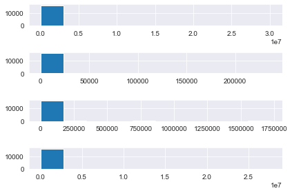

```python
plt.subplot(4, 1, 1)
plt.hist(recipes.calories)

plt.subplot(4, 1, 2)
plt.hist(recipes.protein)

plt.subplot(4, 1, 3)
plt.hist(recipes.fat)

plt.subplot(4, 1, 4)
plt.hist(recipes.sodium)

plt.tight_layout()
```

```python
#Winsorize right outliers
from scipy.stats.mstats import winsorize
nutrition= nutrition.fillna(nutrition.mean())
nutrition['calories']=winsorize(nutrition.loc[:, 'calories'], (0, 0.05))
nutrition['protein']=winsorize(nutrition.protein, (0, 0.05))
nutrition['fat']=winsorize(nutrition.fat, (0, 0.05))
nutrition['sodium']=winsorize(nutrition.sodium, (0, 0.05))
```

```python
#MinMax Scale variables to 0-1 scale
from sklearn.preprocessing import MinMaxScaler
scaler=MinMaxScaler()
nutrition_arrays= scaler.fit_transform(nutrition)
nutrition=pd.DataFrame(nutrition_arrays, columns=nutrition.columns)
nutrition_w_ratings= pd.concat([nutrition, recipes.Great], axis=1)
nutrition_w_ratings[nutrition_w_ratings.calories==1]['Great'].mean()
```

```
0.7504803073967339
```

```python
#Add nutritional columns to featureset
X2=recipes[top_feats.index]
X2=pd.concat([X2, nutrition], axis=1)
X2=X2.sample(frac=0.35, replace=True)
```

```python
#Split new data
X_train, X_test, Y_train, Y_test=train_test_split(X2, Y, test_size=0.1)
```

```python
#Split data for oversampling
feat_train, feat_val, y_train, y_val= train_test_split(X_train, Y_train, test_size=0.1)
```

```python
#Create balanced classes to train model
from imblearn.over_sampling import SMOTE
sm=SMOTE(ratio=1.0)
x_train_res, y_train_res= sm.fit_sample(feat_train, y_train)
```

```python
#Find best SVC parameters for new featureset
Cs = [0.01, 0.1, 1, 10, 100]
gammas = [0.0001, 0.001, 0.01, 0.1]
param_grid = {'C': Cs, 'gamma' : gammas}
grid_search = GridSearchCV(SVC(), param_grid, cv=5, n_jobs=-1, verbose=True)
grid_search.fit(x_train_res, y_train_res)
print(grid_search.best_params_)
```

```
Fitting 5 folds for each of 20 candidates, totalling 100 fits
```

```
[Parallel(n_jobs=-1)]: Using backend LokyBackend with 4 concurrent workers.
[Parallel(n_jobs=-1)]: Done  42 tasks      | elapsed:  1.7min
[Parallel(n_jobs=-1)]: Done 100 out of 100 | elapsed:  4.8min finished
```

```
{'C': 100, 'gamma': 0.1}
```

```python
#Fit model
svc=SVC(C=100, gamma=0.1)
svc.fit(x_train_res, y_train_res)
```

```
SVC(C=100, cache_size=200, class_weight=None, coef0=0.0,
    decision_function_shape='ovr', degree=3, gamma=0.1, kernel='rbf',
    max_iter=-1, probability=False, random_state=None, shrinking=True,
    tol=0.001, verbose=False)
```

```python
svc.score(feat_val, y_val)
```

```
0.5569620253164557
```

```python
#Score model
cross_val_score(svc, feat_val, y_val, cv=5)
```

```
array([0.72440945, 0.71653543, 0.73015873, 0.70634921, 0.70634921])
```

```python
preds= svc.predict(feat_val)
ctab= pd.crosstab(y_val, preds, margins=True)
ctab
```

| col_0 Great | 0 | 1 | All |
| --- | --- | --- | --- |
| 0 | 63 | 74 | 137 |
| 1 | 206 | 289 | 495 |
| All | 269 | 363 | 632 |

```python
type1_errors=ctab.loc[1, 1]/ctab.loc['All', 1]*100
type2_errors=ctab.loc[0, 0]/ctab.loc['All', 0]*100
print('Precision for Great Ratings: {0:.2f}%'.format(type1_errors))
print('Precision for Average Ratings: {0:.2f}%'.format(type2_errors))
print('Recall for Great Ratings: {0:.2f}%'.format(ctab.loc[1, 1]/ctab.loc[1, 'All']*100))
print('Recall for Average Ratings: {0:.2f}%'.format(ctab.loc[0, 0]/ctab.loc[0, 'All']*100))
```

```
Precision for Great Ratings: 79.61%
Precision for Average Ratings: 23.42%
Recall for Great Ratings: 58.38%
Recall for Average Ratings: 45.99%
```

Precision is very poor for minority class-how do we fix this?

```python
#Use all variables to see how naive SVM operates
X3=recipes.drop(['title', 'rating', 'Great', 'rating bin'], 1)
Y=recipes.Great.sample(frac= 0.35, replace=True)
```

```python
X3= X3.fillna(X3.mean()).sample(frac= 0.35, replace=True)
```

```python
#Split new data
X_train, X_test, Y_train, Y_test=train_test_split(X3, Y, test_size=0.1)
```

```python
svc.fit(X_train, Y_train)
```

```
SVC(C=100, cache_size=200, class_weight=None, coef0=0.0,
    decision_function_shape='ovr', degree=3, gamma=0.1, kernel='rbf',
    max_iter=-1, probability=False, random_state=None, shrinking=True,
    tol=0.001, verbose=False)
```

```python
svc.score(X_test, Y_test)
```

```
0.7621082621082621
```

```python
pd.crosstab(Y_test, svc.predict(X_test))
```

| col_0 Great | 0 | 1 |
| --- | --- | --- |
| 0 | 11 | 131 |
| 1 | 36 | 524 |

```python
svc.score(X_test, Y_test)
```

```
0.7621082621082621
```

```python
pd.crosstab(Y_test, svc.predict(X_test), margins=True)
```

| col_0 Great | 0 | 1 | All |
| --- | --- | --- | --- |
| 0 | 11 | 131 | 142 |
| 1 | 36 | 524 | 560 |
| All | 47 | 655 | 702 |

```python
X4=recipes[top_ingredients.index]
X4=X4.sample(frac=0.35, replace=True)
```

```python
#Split new data
X_train, X_test, Y_train, Y_test=train_test_split(X4, Y, test_size=0.1)
```

```python
#Find best SVC parameters for new featureset
Cs = [0.01, 0.1, 1, 10, 100]
gammas = [0.0001, 0.001, 0.01, 0.1]
param_grid = {'C': Cs, 'gamma' : gammas}
grid_search = GridSearchCV(SVC(), param_grid, cv=5, n_jobs=-1, verbose=True)
grid_search.fit(X_train, Y_train)
print(grid_search.best_params_)
```

```
Fitting 5 folds for each of 20 candidates, totalling 100 fits
```

```
[Parallel(n_jobs=-1)]: Using backend LokyBackend with 4 concurrent workers.
[Parallel(n_jobs=-1)]: Done  42 tasks      | elapsed:   21.8s
[Parallel(n_jobs=-1)]: Done 100 out of 100 | elapsed:  2.0min finished
```

```
{'C': 0.01, 'gamma': 0.0001}
```

```python
svc=SVC(C=0.01, gamma=0.0001)
svc.fit(X_train, Y_train)
```

```
SVC(C=0.01, cache_size=200, class_weight=None, coef0=0.0,
    decision_function_shape='ovr', degree=3, gamma=0.0001, kernel='rbf',
    max_iter=-1, probability=False, random_state=None, shrinking=True,
    tol=0.001, verbose=False)
```

```python
svc.score(X_train, Y_train)
```

```
0.795598480050665
```

```python
pd.crosstab(Y_train, svc.predict(X_train), margins=True)
```

| col_0 Great | 1 | All |
| --- | --- | --- |
| 0 | 1291 | 1291 |
| 1 | 5025 | 5025 |
| All | 6316 | 6316 |

```python
svc.score(X_test, Y_test)
```

```
0.7621082621082621
```